# ExtraaLearn Project

## Context

The EdTech industry has been surging in the past decade immensely, and according to a forecast, the Online Education market would be worth $286.62bn by 2023 with a compound annual growth rate (CAGR) of 10.26% from 2018 to 2023. The modern era of online education has enforced a lot in its growth and expansion beyond any limit. Due to having many dominant features like ease of information sharing, personalized learning experience, transparency of assessment, etc, it is now preferable to traditional education.

In the present scenario due to the Covid-19, the online education sector has witnessed rapid growth and is attracting a lot of new customers. Due to this rapid growth, many new companies have emerged in this industry. With the availability and ease of use of digital marketing resources, companies can reach out to a wider audience with their offerings. The customers who show interest in these offerings are termed as leads. There are various sources of obtaining leads for Edtech companies, like

- The customer interacts with the marketing front on social media or other online platforms.
- The customer browses the website/app and downloads the brochure
- The customer connects through emails for more information.

The company then nurtures these leads and tries to convert them to paid customers. For this, the representative from the organization connects with the lead on call or through email to share further details.

## Objective

ExtraaLearn is an initial stage startup that offers programs on cutting-edge technologies to students and professionals to help them upskill/reskill. With a large number of leads being generated on a regular basis, one of the issues faced by ExtraaLearn is to identify which of the leads are more likely to convert so that they can allocate resources accordingly. You, as a data scientist at ExtraaLearn, have been provided the leads data to:

- Analyze and build an ML model to help identify which leads are more likely to convert to paid customers,
- Find the factors driving the lead conversion process
- Create a profile of the leads which are likely to convert

## Data Description

The data contains the different attributes of leads and their interaction details with ExtraaLearn. The detailed data dictionary is given below.

**Data Dictionary**

- ID: ID of the lead
- age: Age of the lead
- current_occupation: Current occupation of the lead. Values include 'Professional','Unemployed',and 'Student'
- first_interaction: How did the lead first interacted with ExtraaLearn. Values include 'Website', 'Mobile App'
- profile_completed: What percentage of profile has been filled by the lead on the website/mobile app. Values include Low - (0-50%), Medium - (50-75%), High (75-100%)
- website_visits: How many times has a lead visited the website
- time_spent_on_website: Total time spent on the website
- page_views_per_visit: Average number of pages on the website viewed during the visits.
- last_activity: Last interaction between the lead and ExtraaLearn.
  - Email Activity: Seeking for details about program through email, Representative shared information with lead like brochure of program , etc
  - Phone Activity: Had a Phone Conversation with representative, Had conversation over SMS with representative, etc
  - Website Activity: Interacted on live chat with representative, Updated profile on website, etc
- print_media_type1: Flag indicating whether the lead had seen the ad of ExtraaLearn in the Newspaper.
- print_media_type2: Flag indicating whether the lead had seen the ad of ExtraaLearn in the Magazine.
- digital_media: Flag indicating whether the lead had seen the ad of ExtraaLearn on the digital platforms.
- educational_channels: Flag indicating whether the lead had heard about ExtraaLearn in the education channels like online forums, discussion threads, educational websites, etc.
- referral: Flag indicating whether the lead had heard about ExtraaLearn through reference.
- status: Flag indicating whether the lead was converted to a paid customer or not.

## Importing necessary libraries and data

```python
import pandas as pd
import numpy as np
import matplotlib.pyplot as plt
import seaborn as sns

# To scale the data using z-score
from sklearn.preprocessing import StandardScaler
from sklearn.model_selection import train_test_split

# Algorithms to use
from sklearn.linear_model import LogisticRegression

from sklearn.svm import SVC

from sklearn.tree import DecisionTreeClassifier

## Ensemble techniques
from sklearn.ensemble import BaggingClassifier
from sklearn.ensemble import RandomForestClassifier

# Metrics to evaluate the model
from sklearn import metrics
from sklearn.metrics import confusion_matrix, accuracy_score, classification_report, precision_recall_curve, recall_score
from sklearn import tree

# For tuning the model
from sklearn.model_selection import GridSearchCV

# To ignore warinings
import warnings
warnings.filterwarnings("ignore")
```

## Data Overview

- Observations
- Sanity checks

```python
df = pd.read_csv('ExtraaLearn.csv')
```

```python
# View the head data
df.head()
```

|  | ID | age | current_occupation | first_interaction | profile_completed | website_visits | time_spent_on_website | page_views_per_visit | last_activity | print_media_type1 | print_media_type2 | digital_media | educational_channels | referral | status |
| --- | --- | --- | --- | --- | --- | --- | --- | --- | --- | --- | --- | --- | --- | --- | --- |
| 0 | EXT001 | 57 | Unemployed | Website | High | 7 | 1639 | 1.861 | Website Activity | Yes | No | Yes | No | No | 1 |
| 1 | EXT002 | 56 | Professional | Mobile App | Medium | 2 | 83 | 0.320 | Website Activity | No | No | No | Yes | No | 0 |
| 2 | EXT003 | 52 | Professional | Website | Medium | 3 | 330 | 0.074 | Website Activity | No | No | Yes | No | No | 0 |
| 3 | EXT004 | 53 | Unemployed | Website | High | 4 | 464 | 2.057 | Website Activity | No | No | No | No | No | 1 |
| 4 | EXT005 | 23 | Student | Website | High | 4 | 600 | 16.914 | Email Activity | No | No | No | No | No | 0 |

```python
# View complete info
df.info()
```

```
<class 'pandas.core.frame.DataFrame'>
RangeIndex: 4612 entries, 0 to 4611
Data columns (total 15 columns):
 #   Column                 Non-Null Count  Dtype
---  ------                 --------------  -----
 0   ID                     4612 non-null   object
 1   age                    4612 non-null   int64
 2   current_occupation     4612 non-null   object
 3   first_interaction      4612 non-null   object
 4   profile_completed      4612 non-null   object
 5   website_visits         4612 non-null   int64
 6   time_spent_on_website  4612 non-null   int64
 7   page_views_per_visit   4612 non-null   float64
 8   last_activity          4612 non-null   object
 9   print_media_type1      4612 non-null   object
 10  print_media_type2      4612 non-null   object
 11  digital_media          4612 non-null   object
 12  educational_channels   4612 non-null   object
 13  referral               4612 non-null   object
 14  status                 4612 non-null   int64
dtypes: float64(1), int64(4), object(10)
memory usage: 540.6+ KB
```

#### Observations:

- There are **4612 observations** across **15 columns** in the dataset
- There are **no missing values** in the dataset

```python
# Check for unique values in each column
df.nunique()
```

```
ID                       4612
age                        46
current_occupation          3
first_interaction           2
profile_completed           3
website_visits             27
time_spent_on_website    1623
page_views_per_visit     2414
last_activity               3
print_media_type1           2
print_media_type2           2
digital_media               2
educational_channels        2
referral                    2
status                      2
dtype: int64
```

## Exploratory Data Analysis (EDA)

- EDA is an important part of any project involving data.
- It is important to investigate and understand the data better before building a model with it.
- A few questions have been mentioned below which will help you approach the analysis in the right manner and generate insights from the data.
- A thorough analysis of the data, in addition to the questions mentioned below, should be done.

**Questions**

1. Leads will have different expectations from the outcome of the course and the current occupation may play a key role in getting them to participate in the program. Find out how current occupation affects lead status.
2. The company's first impression on the customer must have an impact. Do the first channels of interaction have an impact on the lead status?
3. The company uses multiple modes to interact with prospects. Which way of interaction works best?
4. The company gets leads from various channels such as print media, digital media, referrals, etc. Which of these channels have the highest lead conversion rate?
5. People browsing the website or mobile application are generally required to create a profile by sharing their personal data before they can access additional information.Does having more details about a prospect increase the chances of conversion?

## Data Preprocessing

- Missing value treatment (if needed)
- Feature engineering (if needed)
- Outlier detection and treatment (if needed)
- Preparing data for modeling
- Any other preprocessing steps (if needed)

```python
# Drop ID column
df.drop(['ID'],axis=1)
```

|  | age | current_occupation | first_interaction | profile_completed | website_visits | time_spent_on_website | page_views_per_visit | last_activity | print_media_type1 | print_media_type2 | digital_media | educational_channels | referral | status |
| --- | --- | --- | --- | --- | --- | --- | --- | --- | --- | --- | --- | --- | --- | --- |
| 0 | 57 | Unemployed | Website | High | 7 | 1639 | 1.861 | Website Activity | Yes | No | Yes | No | No | 1 |
| 1 | 56 | Professional | Mobile App | Medium | 2 | 83 | 0.320 | Website Activity | No | No | No | Yes | No | 0 |
| 2 | 52 | Professional | Website | Medium | 3 | 330 | 0.074 | Website Activity | No | No | Yes | No | No | 0 |
| 3 | 53 | Unemployed | Website | High | 4 | 464 | 2.057 | Website Activity | No | No | No | No | No | 1 |
| 4 | 23 | Student | Website | High | 4 | 600 | 16.914 | Email Activity | No | No | No | No | No | 0 |
| ... | ... | ... | ... | ... | ... | ... | ... | ... | ... | ... | ... | ... | ... | ... |
| 4607 | 35 | Unemployed | Mobile App | Medium | 15 | 360 | 2.170 | Phone Activity | No | No | No | Yes | No | 0 |
| 4608 | 55 | Professional | Mobile App | Medium | 8 | 2327 | 5.393 | Email Activity | No | No | No | No | No | 0 |
| 4609 | 58 | Professional | Website | High | 2 | 212 | 2.692 | Email Activity | No | No | No | No | No | 1 |
| 4610 | 57 | Professional | Mobile App | Medium | 1 | 154 | 3.879 | Website Activity | Yes | No | No | No | No | 0 |
| 4611 | 55 | Professional | Website | Medium | 4 | 2290 | 2.075 | Phone Activity | No | No | No | No | No | 0 |

4612 rows × 14 columns

```python
# Create numerical columns
num_cols=['age','website_visits','time_spent_on_website','page_views_per_visit']

# Create categorical columns
cat_cols=['current_occupation','first_interaction','profile_completed','last_activity','print_media_type1',
          'print_media_type2','digital_media','referral','status']
```

## EDA

- It is a good idea to explore the data once again after manipulating it.

#### Univariate analysis of numerical columns

```python
df[num_cols].describe().T
```

|  | count | mean | std | min | 25% | 50% | 75% | max |
| --- | --- | --- | --- | --- | --- | --- | --- | --- |
| age | 4612.0 | 46.201214 | 13.161454 | 18.0 | 36.00000 | 51.000 | 57.00000 | 63.000 |
| website_visits | 4612.0 | 3.566782 | 2.829134 | 0.0 | 2.00000 | 3.000 | 5.00000 | 30.000 |
| time_spent_on_website | 4612.0 | 724.011275 | 743.828683 | 0.0 | 148.75000 | 376.000 | 1336.75000 | 2537.000 |
| page_views_per_visit | 4612.0 | 3.026126 | 1.968125 | 0.0 | 2.07775 | 2.792 | 3.75625 | 18.434 |

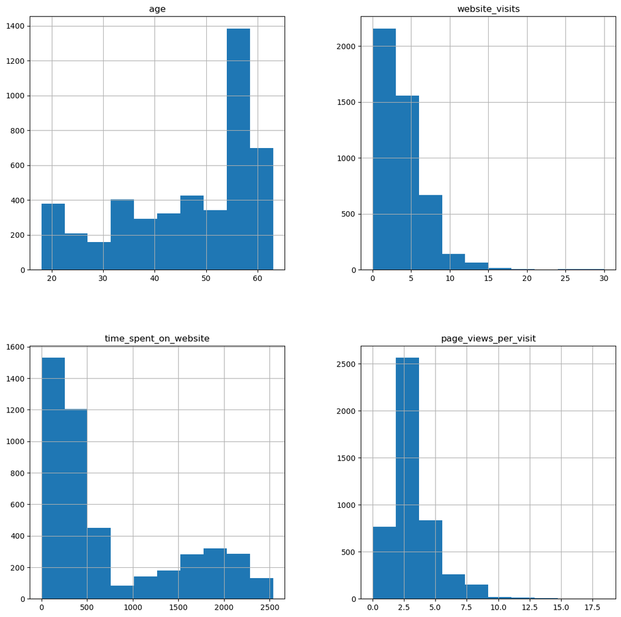

```python
# Histogram visualizations of numerical categories
df[num_cols].hist(figsize=(14,14))
plt.show()
```

#### Univariate analysis for categorical variables

```python
for i in cat_cols:
    print(df[i].value_counts(normalize=True))
    print('*'*40)
```

```
Professional    0.567216
Unemployed      0.312446
Student         0.120338
Name: current_occupation, dtype: float64
Website       0.551171
Mobile App    0.448829
Name: first_interaction, dtype: float64
High      0.490893
Medium    0.485906
Low       0.023200
Name: profile_completed, dtype: float64
Email Activity      0.493929
Phone Activity      0.267563
Website Activity    0.238508
Name: last_activity, dtype: float64
No     0.892238
Yes    0.107762
Name: print_media_type1, dtype: float64
No     0.94948
Yes    0.05052
Name: print_media_type2, dtype: float64
No     0.885733
Yes    0.114267
Name: digital_media, dtype: float64
No     0.979835
Yes    0.020165
Name: referral, dtype: float64
0    0.701431
1    0.298569
Name: status, dtype: float64
```

#### Observations:

- approx. **30% of leads have been converted** to customers according to the data
- Only **2%** of the leads had been referred to the site
- Only a small percentage of leads have been influenced by media (newspaper, magazine, digital)
- Approx. **50%** were linked through email activity
- Phone and website activity follow behind email activity at around **25%** each
- Approx. **50%** of leads had completed their online profiles to near completion
- **Website and Mobile site** first interaction of leads is nearly **evenly split** 50/50

#### Bivariate and Multivariate analysis

How does status relate with the various categorical variables?

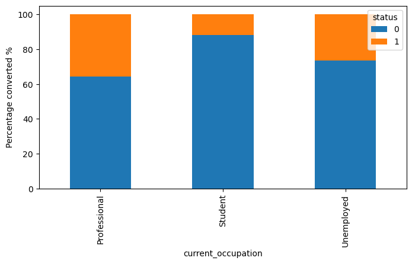

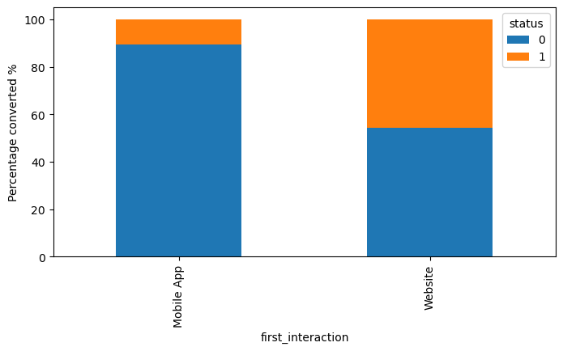

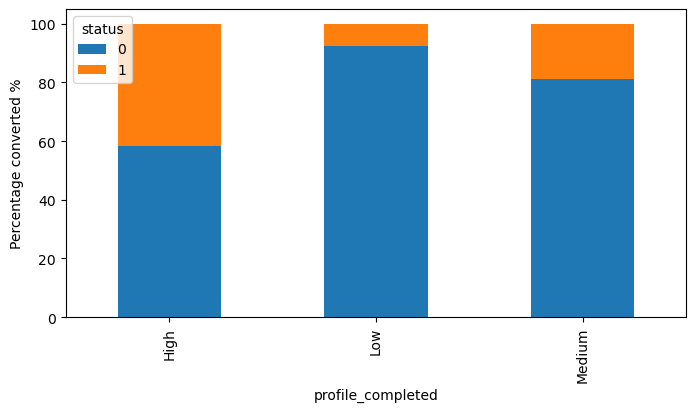

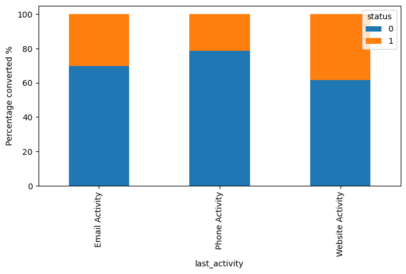

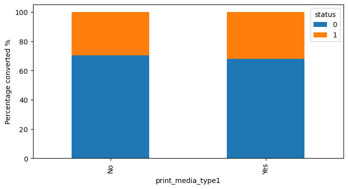

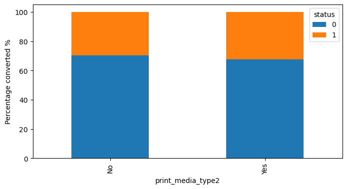

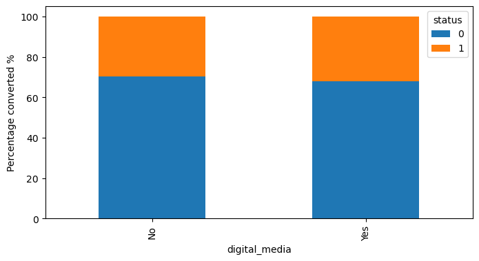

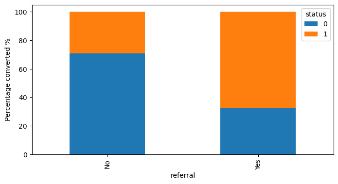

```python
for i in cat_cols:
    if i != 'status':
        (pd.crosstab(df[i], df['status'], normalize='index')*100).plot(kind='bar', figsize=(8,4),stacked=True)
        plt.ylabel('Percentage converted %')
```

#### Observations:

- **Website** first-interactions were responsible for approx. **45%** conversions, which is more than double the conversions from mobile app interactions.
- Leads whose online profile was near completion were converted **>40%** of the time, compared with low completion where conversion was <10%
- Newspaper, Print and Digital media exposure influence on conversion was almost identical across each category (perhaps negligible)
- The most interesting category so far seems to be a referral, which appears to have a near **70%** conversion rate for leads
- The referral data is particularly interesting due to the fact that merely **2%** of leads had been referred.

### Let's check the correlation matrix between the numerical category data...

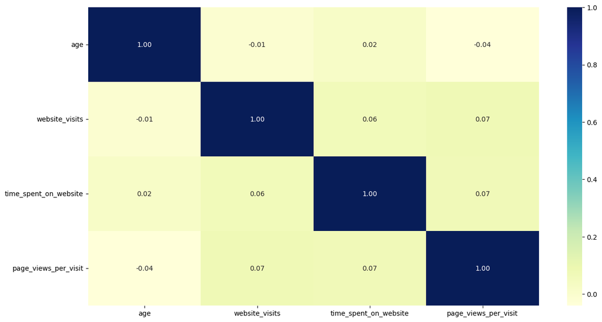

```python
# Plot the correlation b/n numerical variables
plt.figure(figsize=(15,8))
sns.heatmap(df[num_cols].corr(), annot=True, fmt='0.2f', cmap='YlGnBu')
```

### Data preparation

#### Create dummy variables for category variables

```python
# Dummy columns
to_get_dummies_for = cat_cols

# Dummy variables
df = pd.get_dummies(data=df,columns=to_get_dummies_for,drop_first=True)
df.columns = df.columns.str.split('_', 1).str[0]

# # Map educational
dict_educational = {'Yes': 1, 'No': 0}

df['educational'] = df.educational.map(dict_educational)
print(df)
```

```
           ID  age  website  time    page  educational  current  current  \
0      EXT001   57        7  1639   1.861            0        0        1
1      EXT002   56        2    83   0.320            1        0        0
2      EXT003   52        3   330   0.074            0        0        0
3      EXT004   53        4   464   2.057            0        0        1
4      EXT005   23        4   600  16.914            0        1        0
...       ...  ...      ...   ...     ...          ...      ...      ...
4607  EXT4608   35       15   360   2.170            1        0        1
4608  EXT4609   55        8  2327   5.393            0        0        0
4609  EXT4610   58        2   212   2.692            0        0        0
4610  EXT4611   57        1   154   3.879            0        0        0
4611  EXT4612   55        4  2290   2.075            0        0        0

      first  profile  profile  last  last  print  print  digital  referral  \
0         1        0        0     0     1      1      0        1         0
```

[output cut: 25 more lines]

#### Separate the independent variables (X) and the target/dependent variable (Y)

```python
Y = df.status
X = df.drop(columns = ['status', 'ID'])
```

```python
# Split the data into 70% train and 30% test
X_train, X_test, y_train, y_test = train_test_split(X, Y, test_size = 0.3, random_state = 1, stratify = Y)
```

## Building a Decision Tree model

```python
# Build decision tree model
dt = DecisionTreeClassifier(class_weight = {0: 0.30, 1: 0.70}, random_state = 1)

# Fit decision tree model
dt.fit(X_train, y_train)
```

```
DecisionTreeClassifier(class_weight={0: 0.3, 1: 0.7}, random_state=1)
```

```python
# Create metrics function
def metrics_score(actual, predicted):
    print(classification_report(actual, predicted))

    cm = confusion_matrix(actual, predicted)
    plt.figure(figsize=(8,5))

    sns.heatmap(cm, annot=True,  fmt='.2f', xticklabels=['Not Converted', 'Converted'], yticklabels=['Not Converted', 'Converted'])
    plt.ylabel('Actual')
    plt.xlabel('Predicted')
    plt.show()
```

```
              precision    recall  f1-score   support

           0       1.00      1.00      1.00      2264
           1       1.00      1.00      1.00       964

    accuracy                           1.00      3228
   macro avg       1.00      1.00      1.00      3228
weighted avg       1.00      1.00      1.00      3228
```

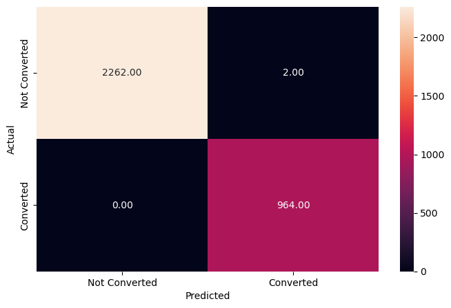

```python
# Checking performance on the training dataset
y_train_pred_dt = dt.predict(X_train)

metrics_score(y_train, y_train_pred_dt)
```

```
              precision    recall  f1-score   support

           0       0.84      0.86      0.85       971
           1       0.65      0.62      0.63       413

    accuracy                           0.79      1384
   macro avg       0.75      0.74      0.74      1384
weighted avg       0.78      0.79      0.79      1384
```

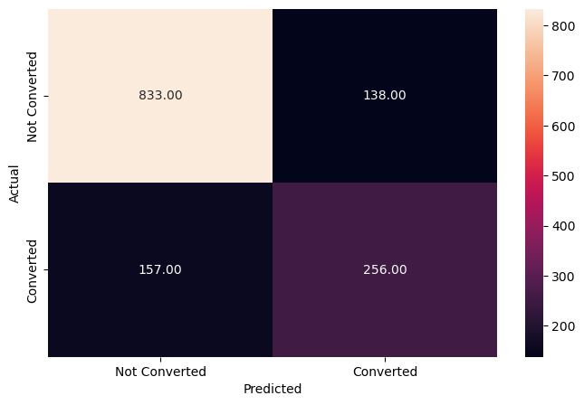

```python
# Checking performance on the test dataset
y_test_pred_dt = dt.predict(X_test)

metrics_score(y_test, y_test_pred_dt)
```

#### Observations:

- According to the above results, the results seem unrealistic due to the **100% score** on all metrics (overfitting)
- The decision tree works well on the training set, but not well on the test data as the recall is **62%** compared to 1 for the training set
- The test data model precision suggests that there's a 35% chance the model will falsely predict a conversion
- Due to these results, the company may falsely attribute significance to non-success indicator categories

## Do we need to prune the tree?

- According to the results above, it seems that a pruning would help prevent the overfitting

#### First, let's visualize our decision tree

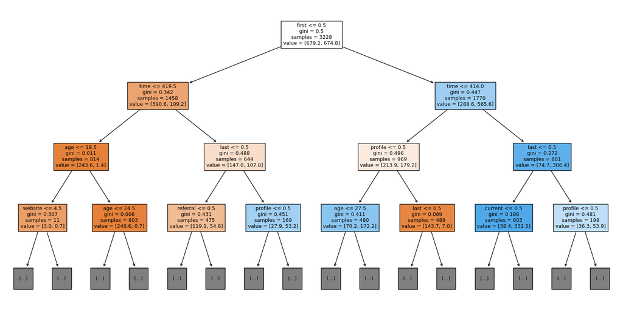

```python
feature_names = list(X_train.columns)
plt.figure(figsize=(20, 10))
out = tree.plot_tree(
    dt,
    max_depth=3,
    feature_names=feature_names,
    filled=True,
    fontsize=9,
    node_ids=False,
    class_names=None,
)
# below code will add arrows to the decision tree split if they are missing
for o in out:
    arrow = o.arrow_patch
    if arrow is not None:
        arrow.set_edgecolor("black")
        arrow.set_linewidth(1)
plt.show()
```

```python
# Pre-pruning
params = {
    'max_depth': [2,4,6,8,10,12],
    'min_samples_split': [2,3,4],
    'min_samples_leaf': [1,2]
}

clf = tree.DecisionTreeClassifier()
gcv = GridSearchCV(estimator=clf, param_grid=params)
gcv.fit(X_train, y_train)
```

```
GridSearchCV(estimator=DecisionTreeClassifier(),
             param_grid={'max_depth': [2, 4, 6, 8, 10, 12],
                         'min_samples_leaf': [1, 2],
                         'min_samples_split': [2, 3, 4]})
```

```python
model = gcv.best_estimator_
model.fit(X_train,y_train)
y_train_pred = model.predict(X_train)
y_test_pred = model.predict(X_test)

print(f'Train score {accuracy_score(y_train_pred,y_train)}')
print(f'Test score {accuracy_score(y_test_pred,y_test)}')
```

```
Train score 0.8937422552664188
Test score 0.8526011560693642
```

[figure not shown]

```python
# Display our improved tree
plt.figure(figsize=(20,20))
features = df.columns
classes = ['Not converted','converted']
tree.plot_tree(model,feature_names=features,class_names=classes,filled=True)
plt.show()
```

```python
# Let's implement post-pruning (cost-complexity pruning)
y_pred = dt.predict(X_test)
initial_accuracy = accuracy_score(y_test, y_pred)

path = dt.cost_complexity_pruning_path(X_train, y_train)
ccp_alphas = path.ccp_alphas[:-1] # full tree excluding max alpha
clfs = []
for ccp_alpha in ccp_alphas:
    clf = DecisionTreeClassifier(random_state=1, ccp_alpha=ccp_alpha)
    clf.fit(X_train, y_train)
    clfs.append(clf)

# Evaluate the pruned models and select the best
best_accuracy = initial_accuracy
best_model = dt
for clf in clfs:
    y_pred = clf.predict(X_test)
    accuracy = accuracy_score(y_test, y_pred)
    if accuracy >= best_accuracy:
        best_accuracy = accuracy
        best_model = clf

pruned_dt = best_model
```

[figure not shown]

```python
# Display our post-pruned tree
# Display our improved tree
plt.figure(figsize=(20,20))
features = df.columns
classes = ['Not converted','converted']
tree.plot_tree(pruned_dt,feature_names=features,class_names=classes,filled=True)
plt.show()
```

```python
# Evaluate original tree results
y_pred_original = pruned_dt.predict(X_test)
accuracy_original = accuracy_score(y_test, y_pred_original)
recall_original = recall_score(y_test, y_pred_original)

# Let's evaluate our pruned tree results
y_pred_pruned = pruned_dt.predict(X_test)
accuracy_pruned = accuracy_score(y_test, y_pred_pruned)
recall_pruned = recall_score(y_test, y_pred_pruned)

# Print our results:
print("Original Decision Tree:")
print(f"Accuracy: {accuracy_original:.4f}")
print(f"Recall: {recall_original:.4f}")
print("****************")
print("Pruned Decision Tree:")
print(f"Accuracy: {accuracy_pruned:.4f}")
print(f"Recall: {recall_pruned:.4f}")
```

[output not shown]

## Building a Random Forest model

```python
rf_estimator = RandomForestClassifier(random_state=1)

rf_estimator.fit(X_train, y_train)
```

```
RandomForestClassifier(random_state=1)
```

#### Check performance of model on train and test data

```
              precision    recall  f1-score   support

           0       1.00      1.00      1.00      2264
           1       1.00      1.00      1.00       964

    accuracy                           1.00      3228
   macro avg       1.00      1.00      1.00      3228
weighted avg       1.00      1.00      1.00      3228
```

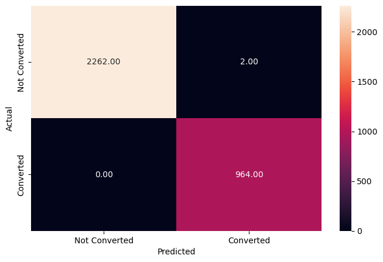

```python
y_pred_train_rf = rf_estimator.predict(X_train)

metrics_score(y_train, y_pred_train_rf)
```

```
              precision    recall  f1-score   support

           0       0.89      0.91      0.90       971
           1       0.78      0.73      0.75       413

    accuracy                           0.86      1384
   macro avg       0.83      0.82      0.83      1384
weighted avg       0.85      0.86      0.85      1384
```

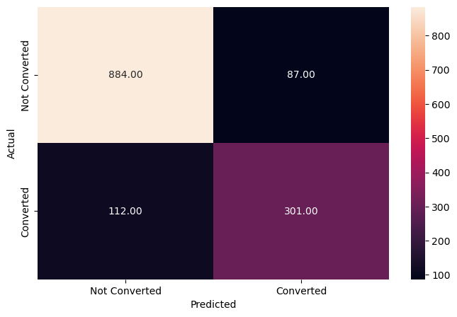

```python
y_pred_test_rf = rf_estimator.predict(X_test)

metrics_score(y_test, y_pred_test_rf)
```

### Feature Importance

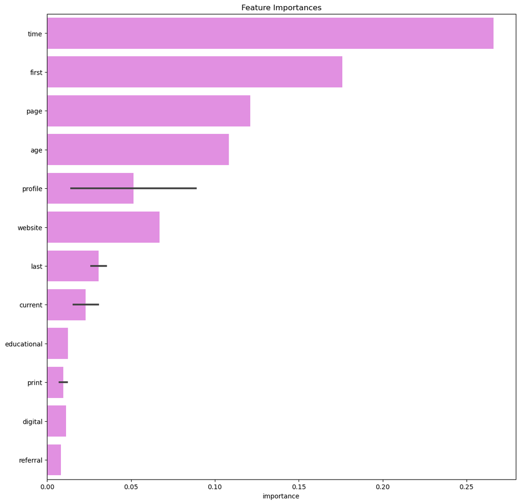

```python
importances = rf_estimator.feature_importances_

columns = X_train.columns

importance_df = pd.DataFrame(importances, index=columns, columns= ['importance']).sort_values(by='importance',ascending=False)
plt.figure(figsize = (13, 13))
plt.title("Feature Importances")
sns.barplot(x = importance_df.importance, y = importance_df.index, color="violet")
```

## Actionable Insights and Recommendations

#### Insights

- According to the feature results, it looks as though **total time spent on website** is the most important feature
- The next three most important features include **first interaction**, **page visits** and **age**